# Capestone Project

James Strayer

02/01/2020

# Introduction

I was given data from a Restaurant that sales some of their product in retail to find a model to predict the sales, The data start from 2015

## Data import and cleaning

```
## Observations: 1,715
## Variables: 11
## $ Date             <date> 2015-03-29, 2015-03-30, 2015-03-31, 2015-04-01, 201…
## $ Weekday          <chr> "SUNDAY", "MONDAY", "TUESDAY", "WEDNESDAY", "THURSDA…
## $ Year             <dbl> 2015, 2015, 2015, 2015, 2015, 2015, 2015, 2015, 2015…
## $ Month            <chr> "March'15", "March'15", "March'15", "April'15", "Apr…
## $ Day              <dbl> 29, 30, 31, 1, 2, 3, 4, 5, 6, 7, 8, 9, 10, 11, 12, 1…
## $ `annee fiscale`  <chr> "2014-15", "2014-15", "2014-15", "2014-15", "2014-15…
## $ Sales            <dbl> 1792.00, NA, 1526.30, 2250.26, 2077.57, 2357.48, 150…
## $ Retail           <dbl> 373.00, NA, 380.95, 363.72, 268.80, 394.23, 476.17, …
## $ TakeOutSales     <dbl> 0.00, 0.00, 99.25, 402.75, 0.00, 32.50, 93.73, 0.00,…
## $ Bar_Sales        <dbl> NA, NA, NA, NA, NA, NA, NA, NA, NA, NA, NA, NA, 227.…
## $ Sales_Restaurant <dbl> 1419.00, 0.00, 1046.10, 1483.79, 1808.77, 1930.75, 9…
```

We can remove the fiscal year .The Month variable is in a format not pratical for analysis (Month, YY) we want to have just the Full moth written without the year. So for simplicity and because we have the full date in the Date column, we are going to remove the month column as it is and create a new one based on the date column, we will do the same for the weekdays column. Furthermore we don’t need the day number in our analysis so we will remove it too:

```r
#Remove unncessary column for the analysis
DataForAnalysis<-DailySales%>%select(-Weekday,-Month,-Day,-`annee fiscale`)
#Add a column for weekday and month
DataForAnalysis<-DataForAnalysis%>%mutate(Weekday=weekdays(Date),Month=months(Date))
```

If we look again at the data we see that we have a Sales column, representing the Total Sales for the day and then each column after it, is the total sales for each day for each component of the restaurant possible sales revenu, so Retail, Take-out, Bar and Restaurant. We can see that there is NAs in all of those data

```r
#looking for NAs in the sales data
sum(is.na(DataForAnalysis$Sales))
```

```
## [1] 175
```

```r
sum(is.na(DataForAnalysis$Bar_Sales))
```

```
## [1] 208
```

```r
sum(is.na(DataForAnalysis$Retail))
```

```
## [1] 188
```

```r
sum(is.na(DataForAnalysis$TakeOutSales))
```

```
## [1] 1
```

```r
sum(is.na(DataForAnalysis$Sales_Restaurant))
```

```
## [1] 1
```

we will change those NAs to 0, considering a $0 CAD sales for that day and variable

```r
#Chaning NAs to 0 in the sales data
DataForAnalysis[is.na(DataForAnalysis$Sales),]$Sales<-0
DataForAnalysis[is.na(DataForAnalysis$Bar_Sales),]$Bar_Sales<-0
DataForAnalysis[is.na(DataForAnalysis$Retail),]$Retail<-0
DataForAnalysis[is.na(DataForAnalysis$TakeOutSales),]$TakeOutSales<-0
DataForAnalysis[is.na(DataForAnalysis$Sales_Restaurant),]$Sales_Restaurant<-0
```

Once we Cleaned the data. We are interested to add some classification for the days, specialy considering that holidays and special event should have an impact on the sales of a restaurant, to test this hypothesis we create a data frame event for all the bank holidays and events in the province of Quebec during the year:

here is an example of the data used to create that data frame: https://www.statutoryholidays.com/2017.php, all dates with observance National, QC and event such as Mother’s day and Valentine’s day. Once this vector is created we can create a new variable called EventDay which is true if the date equals one of the date in the vector

```r
#Add a column for EventDay
DataForAnalysis<-DataForAnalysis%>%mutate(EventDay=ifelse(Date %in% Event,TRUE,FALSE))
```

# Data exploration

```r
#look at the structure of the data
glimpse(DataForAnalysis)
```

```
## Observations: 1,715
## Variables: 10
## $ Date             <date> 2015-03-29, 2015-03-30, 2015-03-31, 2015-04-01, 201…
## $ Year             <dbl> 2015, 2015, 2015, 2015, 2015, 2015, 2015, 2015, 2015…
## $ Sales            <dbl> 1792.00, 0.00, 1526.30, 2250.26, 2077.57, 2357.48, 1…
## $ Retail           <dbl> 373.00, 0.00, 380.95, 363.72, 268.80, 394.23, 476.17…
## $ TakeOutSales     <dbl> 0.00, 0.00, 99.25, 402.75, 0.00, 32.50, 93.73, 0.00,…
## $ Bar_Sales        <dbl> 0.00, 0.00, 0.00, 0.00, 0.00, 0.00, 0.00, 0.00, 0.00…
## $ Sales_Restaurant <dbl> 1419.00, 0.00, 1046.10, 1483.79, 1808.77, 1930.75, 9…
## $ Weekday          <chr> "Sunday", "Monday", "Tuesday", "Wednesday", "Thursda…
## $ Month            <chr> "March", "March", "March", "April", "April", "April"…
## $ EventDay         <lgl> FALSE, FALSE, FALSE, FALSE, FALSE, FALSE, FALSE, FAL…
```

We want to have full years to have the same thing amount of days in the year to predict 2019 weeks. So we filter for 2016 and more

```r
#Summary statistics for the variable
summary(DataForAnalysis)
```

```
##       Date                 Year          Sales            Retail
##  Min.   :2016-01-01   Min.   :2016   Min.   :   0.0   Min.   :   0.0
##  1st Qu.:2016-12-25   1st Qu.:2016   1st Qu.: 756.8   1st Qu.: 160.2
##  Median :2017-12-19   Median :2017   Median :1212.2   Median : 257.7
##  Mean   :2017-12-19   Mean   :2017   Mean   :1229.4   Mean   : 266.5
##  3rd Qu.:2018-12-13   3rd Qu.:2018   3rd Qu.:1703.3   3rd Qu.: 367.9
##  Max.   :2019-12-29   Max.   :2019   Max.   :4360.8   Max.   :1436.9
##   TakeOutSales       Bar_Sales      Sales_Restaurant    Weekday
##  Min.   :   0.00   Min.   :   0.0   Min.   :-2299.8   Length:1437
##  1st Qu.:   0.00   1st Qu.:  70.0   1st Qu.:  358.0   Class :character
##  Median :  64.00   Median : 153.8   Median :  665.0   Mode  :character
##  Mean   :  83.85   Mean   : 177.0   Mean   :  702.0
##  3rd Qu.: 120.00   3rd Qu.: 257.5   3rd Qu.:  985.2
##  Max.   :2965.72   Max.   :1045.0   Max.   : 4284.2
##     Month            EventDay
##  Length:1437        Mode :logical
##  Class :character   FALSE:1437
##  Mode  :character
##
##
##
```

## Sales Variable

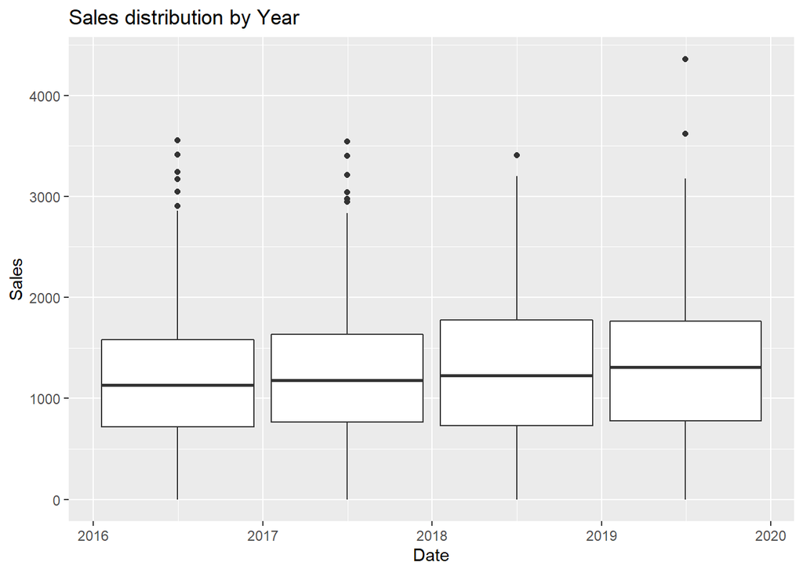

We see In the box plot above that 2019 was similar to 2018 in term of sales but with 2 outliers

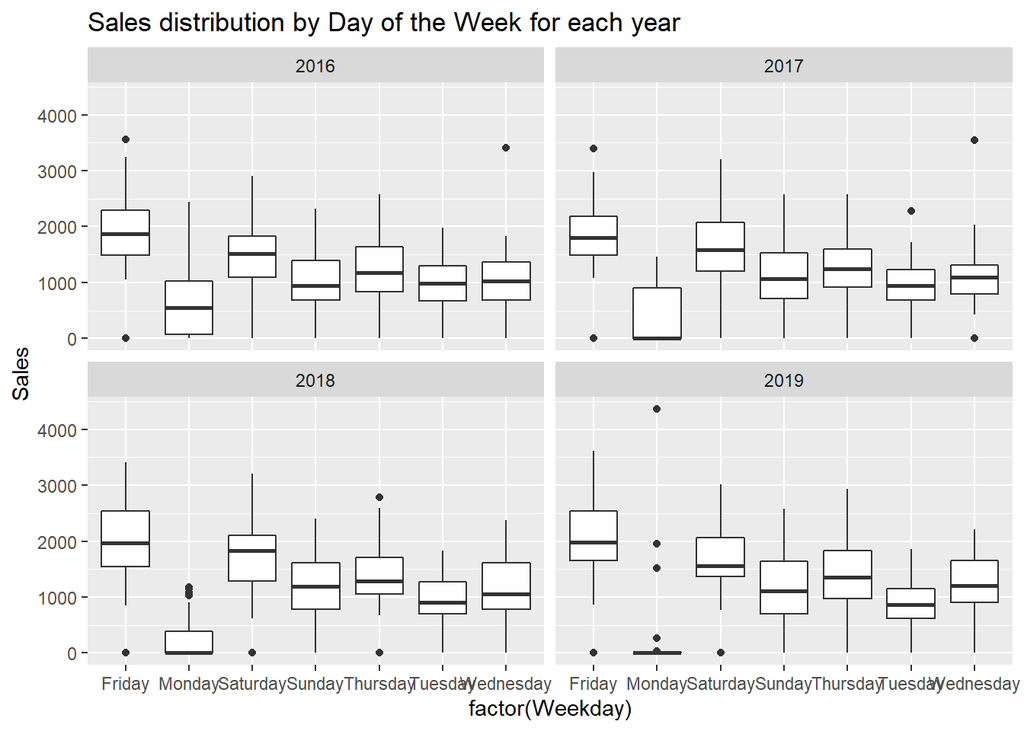

We then transform the data to train and test data. We use 2016 to 2018 to predict 2019 sales data:

# Modeling Data

## ARIMA Model

We are going to test to 2 models to predict sales at a given week knowing the previous weeks. We will wan to try to predict the first week of 2019. We going to compare Linear Regression and ARIMA (Auto Regressive Integrated Moving Average) model (you can have a brief summary of ARIMA model here:https://machinelearningmastery.com/gentle-introduction-box-jenkins-method-time-series-forecasting/)

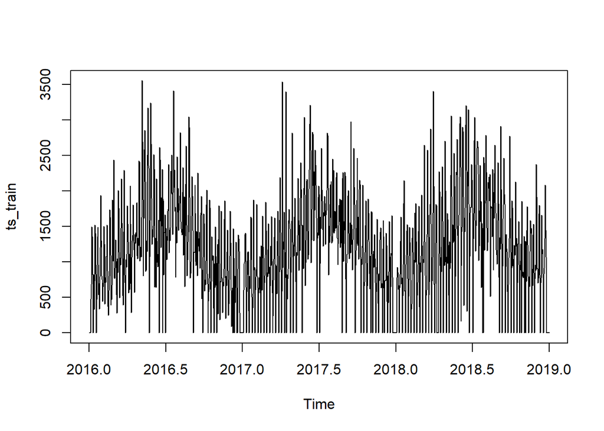

```
## $title
## [1] "Sales Times Series by year"
##
## attr(,"class")
## [1] "labels"
```

```
## Series: ts_train
## ARIMA(7,0,45) with non-zero mean
##
## Coefficients:
##           ar1     ar2      ar3     ar4      ar5     ar6     ar7     ma1
##       -0.1495  0.2724  -0.3419  0.3368  -0.2692  0.1494  0.9960  0.3926
## s.e.   0.0020  0.0023   0.0030  0.0032   0.0014  0.0020  0.0027  0.0301
##           ma2     ma3      ma4     ma5      ma6      ma7      ma8      ma9
##       -0.1160  0.3989  -0.2031  0.3088  -0.0179  -0.8268  -0.1032  -0.0133
## s.e.   0.0335  0.0331   0.0353  0.0370   0.0372   0.0375   0.0440   0.0451
##          ma10     ma11    ma12     ma13     ma14    ma15     ma16    ma17
##       -0.0044  -0.0755  0.0451  -0.0414  -0.0315  0.0572  -0.0697  0.0136
## s.e.   0.0459   0.0454  0.0449   0.0450   0.0453  0.0475   0.0477  0.0463
##          ma18    ma19    ma20    ma21     ma22    ma23    ma24     ma25    ma26
##       -0.0088  0.0350  0.0282  0.0583  -0.0049  0.0205  0.1276  -0.0248  0.0171
## s.e.   0.0443  0.0431  0.0449  0.0499   0.0458  0.0455  0.0459   0.0449  0.0476
##          ma27     ma28    ma29     ma30     ma31    ma32    ma33     ma34
##       -0.0290  -0.0755  0.0150  -0.0551  -0.0471  0.0324  0.0988  -0.0220
## s.e.   0.0489   0.0460  0.0452   0.0449   0.0455  0.0438  0.0450   0.0457
##          ma35     ma36     ma37    ma38     ma39     ma40    ma41    ma42
##       -0.0582  -0.0662  -0.0393  0.0696  -0.0118  -0.0278  0.0171  0.0584
## s.e.   0.0452   0.0479   0.0452  0.0451   0.0396   0.0402  0.0402  0.0357
##         ma43    ma44    ma45      mean
##       0.0896  0.0343  0.0018  1083.715
## s.e.  0.0341  0.0343  0.0342  1237.632
##
## sigma^2 estimated as 222582:  log likelihood=-8286.09
## AIC=16680.18   AICc=16685.89   BIC=16950.15
##
## Training set error measures:
##                    ME    RMSE      MAE MPE MAPE      MASE        ACF1
## Training set 2.325613 460.237 344.9813 NaN  Inf 0.5868102 0.002919366
```

| index | .actual | .fitted | .resid |
| --- | --- | --- | --- |
| 2016-01-01 | 0.00 | 312.735464 | -312.7354637 |
| 2016-01-02 | 0.00 | 74.164183 | -74.1641828 |
| 2016-01-03 | 0.00 | 67.832036 | -67.8320362 |
| 2016-01-04 | 0.00 | 58.782847 | -58.7828466 |
| 2016-01-05 | 477.86 | 203.622561 | 274.2374389 |
| 2016-01-06 | 683.36 | 460.567052 | 222.7929478 |
| 2016-01-07 | 920.13 | 505.786199 | 414.3438011 |
| 2016-01-08 | 1496.47 | 463.615909 | 1032.8540915 |
| 2016-01-09 | 1364.75 | 582.129192 | 782.6208083 |
| 2016-01-10 | 821.64 | 492.089339 | 329.5506608 |

[output cut: 1086 more lines]

By looking at the residual we see that most of it is between -1000 and 1000 with quite few outliers, the model seems good considering the quantity of data:

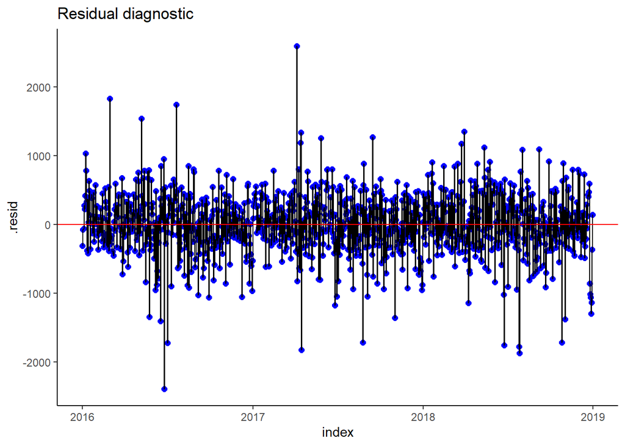

Once we have our model we can forecast the next 365 days of our data,so 2019. We see that the ARIMA(7,0,45) model does not predict the high spikes of sales but still distinguish 7 different pattern, that correspond to the distribution of days of the week.

| index | key | value | lo.80 | lo.95 | hi.80 | hi.95 |
| --- | --- | --- | --- | --- | --- | --- |
| 2016-01-01 | actual | 0.000000 | NA | NA | NA | NA |
| 2016-01-02 | actual | 0.000000 | NA | NA | NA | NA |
| 2016-01-03 | actual | 0.000000 | NA | NA | NA | NA |
| 2016-01-04 | actual | 0.000000 | NA | NA | NA | NA |
| 2016-01-05 | actual | 477.860000 | NA | NA | NA | NA |
| 2016-01-06 | actual | 683.360000 | NA | NA | NA | NA |
| 2016-01-07 | actual | 920.130000 | NA | NA | NA | NA |
| 2016-01-08 | actual | 1496.470000 | NA | NA | NA | NA |
| 2016-01-09 | actual | 1364.750000 | NA | NA | NA | NA |
| 2016-01-10 | actual | 821.640000 | NA | NA | NA | NA |

[output cut: 1451 more lines]

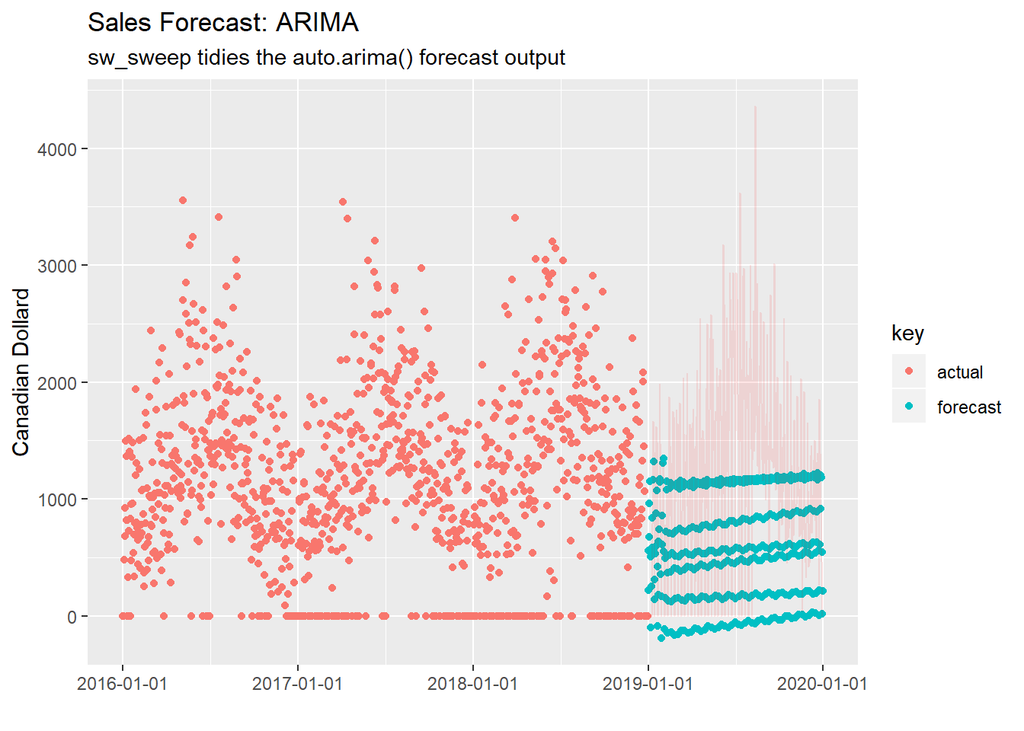

| date | actual | pred | error | error_pct |
| --- | --- | --- | --- | --- |
| 2019-01-01 | 0.00 | 222.644300 | -222.644300 | -Inf |
| 2019-01-02 | 0.00 | 558.429423 | -558.429423 | -Inf |
| 2019-01-03 | 0.00 | 673.487980 | -673.487980 | -Inf |
| 2019-01-04 | 0.00 | 961.857433 | -961.857433 | -Inf |
| 2019-01-05 | 0.00 | 1149.252799 | -1149.252799 | -Inf |
| 2019-01-06 | 0.00 | 506.574988 | -506.574988 | -Inf |
| 2019-01-07 | 0.00 | -99.938492 | 99.938492 | Inf |
| 2019-01-08 | 0.00 | 254.721254 | -254.721254 | -Inf |
| 2019-01-09 | 0.00 | 583.040652 | -583.040652 | -Inf |
| 2019-01-10 | 786.49 | 837.556964 | -51.066964 | -0.064930214 |

[output cut: 355 more lines]

## Linear Regression

To ease the comparison of the models we are going to first transform our full data set to an augmented timeserie, which give us specification on the day, month and years of the Date column. We remove the same variable as the ARIMA model to create our train and test set data for the linear model

| Date | Year | Sales | Retail | TakeOutSales | Bar_Sales | Sales_Restaurant | Weekday | Month | EventDay | index.num | diff | year | year.iso | half | quarter | month | month.xts | month.lbl | day | hour | minute | second | hour12 | am.pm | wday | wday.xts | wday.lbl | mday | qday | … |
| --- | --- | --- | --- | --- | --- | --- | --- | --- | --- | --- | --- | --- | --- | --- | --- | --- | --- | --- | --- | --- | --- | --- | --- | --- | --- | --- | --- | --- | --- | --- |
| 2016-01-01 | 2016 | 0.00 | 0.00 | 0.00 | 0.00 | 0.00 | Friday | January | FALSE | 1451606400 | NA | 2016 | 2015 | 1 | 1 | 1 | 0 | January | 1 | 0 | 0 | 0 | 0 | 1 | 6 | 5 | Friday | 1 | 1 | … |
| 2016-01-02 | 2016 | 0.00 | 0.00 | 0.00 | 0.00 | 0.00 | Saturday | January | FALSE | 1451692800 | 86400 | 2016 | 2015 | 1 | 1 | 1 | 0 | January | 2 | 0 | 0 | 0 | 0 | 1 | 7 | 6 | Saturday | 2 | 2 | … |
| 2016-01-03 | 2016 | 0.00 | 0.00 | 0.00 | 0.00 | 0.00 | Sunday | January | FALSE | 1451779200 | 86400 | 2016 | 2015 | 1 | 1 | 1 | 0 | January | 3 | 0 | 0 | 0 | 0 | 1 | 1 | 0 | Sunday | 3 | 3 | … |
| 2016-01-04 | 2016 | 0.00 | 0.00 | 0.00 | 0.00 | 0.00 | Monday | January | FALSE | 1451865600 | 86400 | 2016 | 2016 | 1 | 1 | 1 | 0 | January | 4 | 0 | 0 | 0 | 0 | 1 | 2 | 1 | Monday | 4 | 4 | … |
| 2016-01-05 | 2016 | 477.86 | 260.86 | 29.50 | 25.75 | 161.75 | Tuesday | January | FALSE | 1451952000 | 86400 | 2016 | 2016 | 1 | 1 | 1 | 0 | January | 5 | 0 | 0 | 0 | 0 | 1 | 3 | 2 | Tuesday | 5 | 5 | … |
| 2016-01-06 | 2016 | 683.36 | 189.22 | 88.00 | 111.00 | 295.14 | Wednesday | January | FALSE | 1452038400 | 86400 | 2016 | 2016 | 1 | 1 | 1 | 0 | January | 6 | 0 | 0 | 0 | 0 | 1 | 4 | 3 | Wednesday | 6 | 6 | … |
| 2016-01-07 | 2016 | 920.13 | 101.89 | 87.75 | 116.00 | 614.49 | Thursday | January | FALSE | 1452124800 | 86400 | 2016 | 2016 | 1 | 1 | 1 | 0 | January | 7 | 0 | 0 | 0 | 0 | 1 | 5 | 4 | Thursday | 7 | 7 | … |
| 2016-01-08 | 2016 | 1496.47 | 287.76 | 102.00 | 262.36 | 844.35 | Friday | January | FALSE | 1452211200 | 86400 | 2016 | 2016 | 1 | 1 | 1 | 0 | January | 8 | 0 | 0 | 0 | 0 | 1 | 6 | 5 | Friday | 8 | 8 | … |
| 2016-01-09 | 2016 | 1364.75 | 346.61 | 114.50 | 164.00 | 739.64 | Saturday | January | FALSE | 1452297600 | 86400 | 2016 | 2016 | 1 | 1 | 1 | 0 | January | 9 | 0 | 0 | 0 | 0 | 1 | 7 | 6 | Saturday | 9 | 9 | … |
| 2016-01-10 | 2016 | 821.64 | 96.64 | 26.00 | 121.00 | 578.00 | Sunday | January | FALSE | 1452384000 | 86400 | 2016 | 2016 | 1 | 1 | 1 | 0 | January | 10 | 0 | 0 | 0 | 0 | 1 | 1 | 0 | Sunday | 10 | 10 | … |

[output cut: 1427 more lines]

We define our linear model such as all the variable defined in our train set is used to predict Sales:

```r
set.seed(42,sample.kind = "Rounding")
fit_Lr<-lm(Sales~.,data=select(trainLr_set,-Date))
summary(fit_Lr)
```

```
##
## Call:
## lm(formula = Sales ~ ., data = select(trainLr_set, -Date))
##
## Residuals:
##      Min       1Q   Median       3Q      Max
## -2364.85  -242.80     9.68   253.26  2497.16
##
## Coefficients: (31 not defined because of singularities)
##                    Estimate Std. Error t value Pr(>|t|)
## (Intercept)      -2.233e+07  7.660e+07  -0.291 0.770728
## Year              4.853e+04  3.350e+04   1.448 0.147795
## WeekdayMonday    -1.036e+03  2.795e+02  -3.707 0.000221 ***
## WeekdaySaturday  -3.548e+02  8.537e+01  -4.156 3.50e-05 ***
## WeekdaySunday    -9.528e+02  1.464e+02  -6.510 1.15e-10 ***
## WeekdayThursday  -4.997e+02  8.718e+01  -5.731 1.30e-08 ***
## WeekdayTuesday   -6.070e+02  2.114e+02  -2.872 0.004161 **
## WeekdayWednesday -5.791e+02  1.464e+02  -3.954 8.18e-05 ***
## MonthAugust       1.459e+04  1.024e+04   1.424 0.154670
## MonthDecember     2.774e+04  2.046e+04   1.356 0.175544
## MonthFebruary    -7.126e+03  6.318e+03  -1.128 0.259620
## MonthJanuary     -1.084e+04  7.496e+03  -1.446 0.148475
## MonthJuly         1.104e+04  7.553e+03   1.461 0.144237
## MonthJune         7.605e+03  7.786e+03   0.977 0.328863
## MonthMarch       -3.668e+03  7.238e+03  -0.507 0.612461
## MonthMay          3.838e+03  3.829e+03   1.002 0.316472
## MonthNovember     2.448e+04  1.764e+04   1.388 0.165424
## MonthOctober      2.100e+04  1.519e+04   1.383 0.167083
## MonthSeptember    1.787e+04  1.357e+04   1.317 0.188141
## index.num        -3.550e-04  1.234e-03  -0.288 0.773618
## diff                     NA         NA      NA       NA
## year                     NA         NA      NA       NA
## year.iso         -3.719e+04  2.497e+04  -1.490 0.136643
## half                     NA         NA      NA       NA
## quarter                  NA         NA      NA       NA
## month                    NA         NA      NA       NA
## month.xts                NA         NA      NA       NA
## month.lbl.L              NA         NA      NA       NA
## month.lbl.Q              NA         NA      NA       NA
## month.lbl.C              NA         NA      NA       NA
```

[output cut: 24 more lines]

```
## yday              3.196e+01  6.285e+01   0.508 0.611245
## mweek            -3.149e+00  1.895e+01  -0.166 0.868059
## week             -9.656e+01  5.611e+01  -1.721 0.085575 .
## week.iso         -7.223e+02  4.756e+02  -1.519 0.129119
## week2             1.089e+02  3.168e+01   3.437 0.000611 ***
## week3             1.990e+01  1.776e+01   1.121 0.262743
## week4            -3.182e+01  1.418e+01  -2.245 0.025004 *
## mday7            -1.338e+01  5.157e+01  -0.259 0.795304
## ---
## Signif. codes:  0 '***' 0.001 '**' 0.01 '*' 0.05 '.' 0.1 ' ' 1
##
## Residual standard error: 467 on 1064 degrees of freedom
##   (1 observation deleted due to missingness)
## Multiple R-squared:  0.6066, Adjusted R-squared:  0.5955
## F-statistic: 54.68 on 30 and 1064 DF,  p-value: < 2.2e-16
```

```r
predict_lr<-predict(fit_Lr,newdata=select(testLr_set,-Date))
error_lr<-testLr_set%>%select(Date,actual=Sales)%>%
  mutate(pred=predict_lr,
         error=actual-predict_lr,
         error_pct=error/actual)
error_lr
```

| Date | actual | pred | error | error_pct |
| --- | --- | --- | --- | --- |
| 2019-01-01 | 0.00 | 621.844578 | -621.8445776 | -Inf |
| 2019-01-02 | 0.00 | 785.132807 | -785.1328069 | -Inf |
| 2019-01-03 | 0.00 | 984.208318 | -984.2083176 | -Inf |
| 2019-01-04 | 0.00 | 1603.519238 | -1603.5192381 | -Inf |
| 2019-01-05 | 0.00 | 1368.384290 | -1368.3842899 | -Inf |
| 2019-01-06 | 0.00 | 889.983569 | -889.9835692 | -Inf |
| 2019-01-07 | 0.00 | 187.545221 | -187.5452205 | -Inf |
| 2019-01-08 | 0.00 | 518.941934 | -518.9419339 | -Inf |
| 2019-01-09 | 0.00 | 666.487011 | -666.4870114 | -Inf |
| 2019-01-10 | 786.49 | 865.562522 | -79.0725222 | -0.1005384966 |

[output cut: 331 more lines]

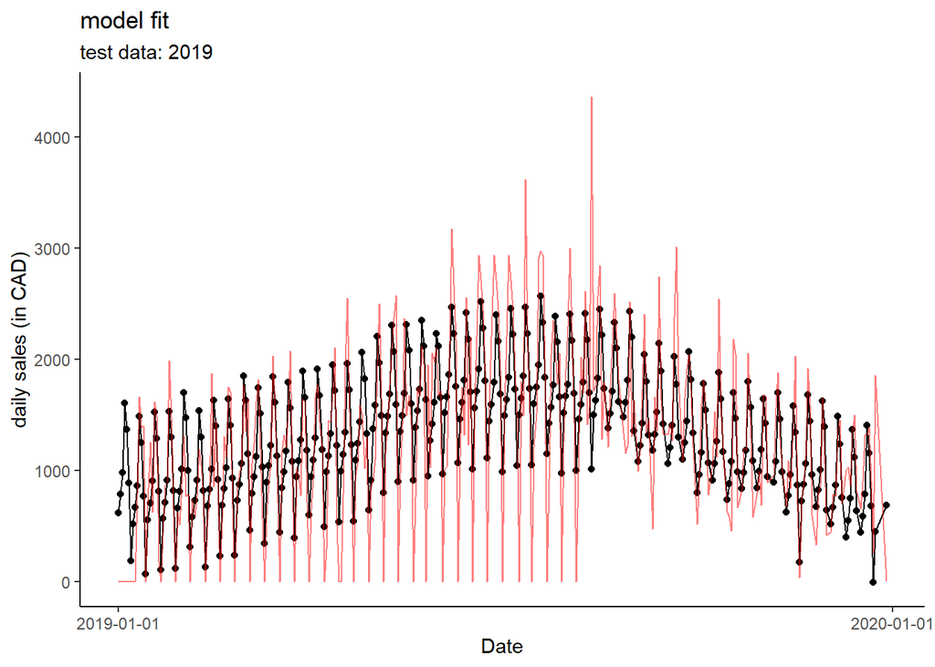

```r
dataToPlot<-testLr_set%>%add_column(pred=predict(fit_Lr,testLr_set)%>%tibble::enframe(name = NULL) %>% pull(value))
dataToPlot %>%
 ggplot(aes(x = Date, y = pred)) +
 geom_line() +
geom_point()+
geom_line(data = testLr_set,aes(x=Date,y=Sales),color="red",alpha=0.5)+
 scale_x_date(date_breaks = "1 year", date_labels = "%F") +
 scale_color_manual(
  values = c(
   "weekly_sales" = "blue",
   "lm_pred" = "#fdc7d7"
  )
 ) +
 theme_classic() +
 labs(title = "model fit",
  subtitle = "test data: 2019",
  x = "Date",
  y = "daily sales (in CAD)"
  )
```

On the plot above we see in red The actual value of sales and in black the prediction made by the linear regression model.

# Discussion